# Breast Cancer Diagnosis

multipathaic package

## Introduction

This vignette demonstrates the **multipathaic** workflow on breast cancer diagnostic data. We apply multi-path forward selection with stability analysis to identify reliable cellular features for distinguishing malignant from benign tumors.

**Key features:** - Multi-path forward selection for classification problems - Bootstrap-based stability analysis - Identification of plausible models combining AIC and stability - Clinical interpretation of selected features

**Dataset:** Fine needle aspirate measurements from 699 breast masses with 9 cellular characteristics.

```r
library(multipathaic)
library(mlbench)
set.seed(2025)
```

## Load Data

```r
data(BreastCancer, package = "mlbench")

# Remove ID and missing values
bc_data <- na.omit(BreastCancer[, -1])

# Convert to numeric (except Class)
for (col in names(bc_data)[-ncol(bc_data)]) {
  bc_data[[col]] <- as.numeric(as.character(bc_data[[col]]))
}

# Binary outcome: malignant = 1, benign = 0
y <- as.numeric(bc_data$Class == "malignant")
X <- as.matrix(bc_data[, -ncol(bc_data)])
X <- scale(X)

print(paste("Data dimensions:", nrow(X), "observations,", ncol(X), "predictors"))
```

```
#> [1] "Data dimensions: 683 observations, 9 predictors"
```

```r
print(paste("Malignant cases:", sum(y), "(", round(100*mean(y), 1), "%)"))
```

```
#> [1] "Malignant cases: 239 ( 35 %)"
```

The dataset contains 9 cellular characteristics measured from fine needle aspirate samples. After removing missing values, we have a binary classification problem with approximately 35% malignant cases.

## Prepare Data

```r
# Stratified 80/20 split
n <- nrow(X)
mal_idx <- which(y == 1)
ben_idx <- which(y == 0)

train_mal <- sample(mal_idx, floor(0.8 * length(mal_idx)))
train_ben <- sample(ben_idx, floor(0.8 * length(ben_idx)))
train_idx <- c(train_mal, train_ben)

X_train <- X[train_idx, ]
y_train <- y[train_idx]
X_test <- X[-train_idx, ]
y_test <- y[-train_idx]

print(paste("Training set:", length(train_idx), "observations"))
```

```
#> [1] "Training set: 546 observations"
```

```r
print(paste("Test set:", length(y_test), "observations"))
```

```
#> [1] "Test set: 137 observations"
```

We use stratified sampling to maintain the proportion of malignant and benign cases in both training and test sets.

## Multi-Path Forward Selection

```r
paths <- build_paths(
  X = X_train,
  y = y_train,
  family = "binomial",
  K = 6,
  eps = 1e-6,
  delta = 2,
  L = 30,
  verbose = FALSE
)

print(paths)
```

```
#> Multi-Path Forward Selection Result
#> ====================================
#> Family: binomial
#> Sample size: 546
#> Number of predictors: 9
#> Steps completed: 6
#> Parameters: eps=1.00e-06, delta=2.00, L=30
#>
#> Models per step:
#>   Step 1: 1 models
#>   Step 2: 1 models
#>   Step 3: 1 models
#>   Step 4: 2 models
#>   Step 5: 3 models
#>   Step 6: 3 models
#>
#> Best model at final step (AIC = 102.94):
#>   Variables: Cell.size, Bare.nuclei, Cl.thickness, Bl.cromatin, Marg.adhesion, Normal.nucleoli
```

For this binary classification problem, we use `family = "binomial"` to fit logistic regression models. The multi-path search explores competitive models at each step.

## Stability Analysis

```r
stab <- stability(
  X = X_train,
  y = y_train,
  family = "binomial",
  B = 20,
  resample_type = "bootstrap",
  K = 6,
  eps = 1e-6,
  delta = 2,
  L = 30,
  verbose = FALSE
)

# Top 5 most stable predictors
head(sort(stab$pi, decreasing = TRUE), 5)
```

```
#>       Cell.size     Bare.nuclei    Cl.thickness     Bl.cromatin Normal.nucleoli
#>       0.9700000       0.7568820       0.7536450       0.4859236       0.3360026
```

Stability analysis reveals which cellular features are most consistently selected across bootstrap resamples, indicating their reliability for cancer diagnosis.

## Plausible Models

```r
plaus <- plausible_models(
  path_result = paths,
  stability_result = stab,
  Delta = 3,
  tau = 0.5,
  remove_duplicates = TRUE,
  refit = FALSE,
  X = X_train,
  y = y_train
)
```

```
#> AIC Filtering:
#>   Total models: 11
#>   Minimum AIC: 102.94
#>   Delta: 3.00
#>   Models within Delta: 4
#>
#> Stability Filtering:
#>   Tau threshold: 0.50
#>   Models with avg stability >= tau: 4
#>
#> Duplicate Removal:
#>   Jaccard threshold: 0.90
#>   Models after removing duplicates: 4
#>
#> ==============================================
#> Final Plausible Model Set: 4 models
#> ==============================================
```

```r
print(plaus)
```

```
#> Plausible Models
#> ================
#> Number of models: 4
#>
#>                                                                       model_id
#> 1 Bare.nuclei+Bl.cromatin+Cell.size+Cl.thickness+Marg.adhesion+Normal.nucleoli
#> 2         Bare.nuclei+Bl.cromatin+Cell.size+Cl.thickness+Marg.adhesion+Mitoses
#> 3      Bare.nuclei+Bl.cromatin+Cell.shape+Cell.size+Cl.thickness+Marg.adhesion
#> 4                 Bare.nuclei+Bl.cromatin+Cell.size+Cl.thickness+Marg.adhesion
#>   size
#> 1    6
#> 2    6
#> 3    6
#> 4    5
#>                                                                           variables
#> 1 Cell.size, Bare.nuclei, Cl.thickness, Bl.cromatin, Marg.adhesion, Normal.nucleoli
#> 2         Cell.size, Bare.nuclei, Cl.thickness, Bl.cromatin, Marg.adhesion, Mitoses
#> 3      Cell.size, Bare.nuclei, Cl.thickness, Bl.cromatin, Marg.adhesion, Cell.shape
#> 4                  Cell.size, Bare.nuclei, Cl.thickness, Bl.cromatin, Marg.adhesion
#>        aic delta_aic avg_stability
#> 1 102.9358 0.0000000     0.5875515
#> 2 103.6913 0.7555586     0.5617901
#> 3 103.7582 0.8224334     0.5654784
#> 4 104.7676 1.8318873     0.6378613
```

We filter for models within `Delta = 3` AIC units of the best model and with average stability `tau ≥ 0.5`. This identifies a set of plausible diagnostic models that balance fit quality and predictor reliability.

## Visualizations

### AIC Progression

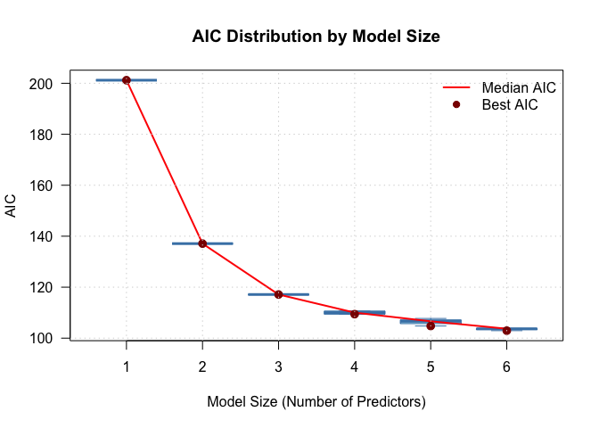

```r
plot_aic_by_step(paths)
```

The AIC decreases sharply with the first few predictors, showing strong discriminative power. The curve flattens after 4-5 features, suggesting a parsimonious diagnostic model is achievable.

### Stability Scores

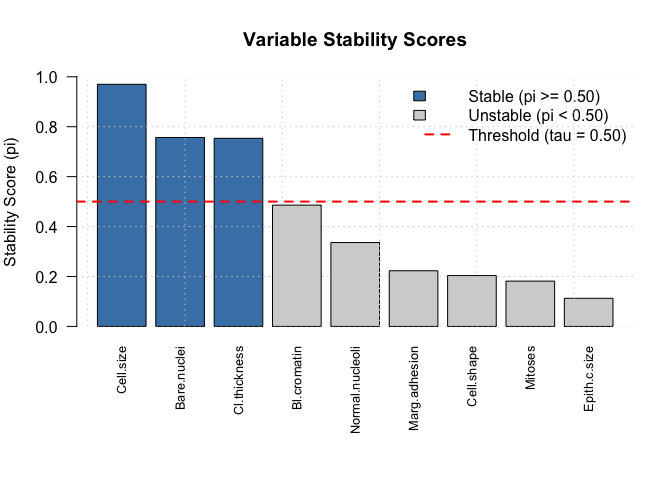

```r
plot_stability(stab, threshold = 0.5)
```

Features with high stability scores (π > 0.7) are the most reliable indicators of malignancy. Cell uniformity measures typically show highest stability, aligning with pathological criteria.

## Test Performance

```r
# Get best model variables
selected_vars <- plaus$variables[[1]]
if (is.character(selected_vars) && length(selected_vars) == 1) {
  selected_vars <- trimws(strsplit(selected_vars, ",")[[1]])
}

# Fit model on training data
X_train_sel <- X_train[, selected_vars, drop = FALSE]
train_data <- data.frame(y = y_train, X_train_sel)
model <- glm(y ~ ., data = train_data, family = binomial)

# Test predictions
X_test_sel <- X_test[, selected_vars, drop = FALSE]
test_data <- data.frame(X_test_sel)
pred_prob <- predict(model, newdata = test_data, type = "response")
pred_class <- as.numeric(pred_prob > 0.5)

# Confusion matrix
cm <- table(Actual = y_test, Predicted = pred_class)
print(cm)
```

```
#>       Predicted
#> Actual  0  1
#>      0 88  1
#>      1  2 46
```

```r
# Calculate metrics
accuracy <- sum(diag(cm)) / sum(cm)
sensitivity <- cm[2, 2] / sum(cm[2, ])
specificity <- cm[1, 1] / sum(cm[1, ])

print(paste("Test Accuracy:", round(100 * accuracy, 1), "%"))
```

```
#> [1] "Test Accuracy: 97.8 %"
```

```r
print(paste("Sensitivity:", round(100 * sensitivity, 1), "%"))
```

```
#> [1] "Sensitivity: 95.8 %"
```

```r
print(paste("Specificity:", round(100 * specificity, 1), "%"))
```

```
#> [1] "Specificity: 98.9 %"
```

```r
print(paste("Model size:", length(selected_vars), "predictors"))
```

```
#> [1] "Model size: 6 predictors"
```

**Clinical Interpretation:** High sensitivity ensures reliable cancer detection (minimizing false negatives), while high specificity reduces unnecessary biopsies (minimizing false positives). The selected model achieves excellent performance on both metrics.

## Summary

This analysis demonstrates the multipathaic workflow for classification:

1. **Data Preparation**: Stratified train-test split maintaining class balance
2. **Multi-Path Search**: Explored multiple competitive logistic regression models
3. **Stability Analysis**: Identified cellular features consistently selected across resamples (B = 20)
4. **Plausible Models**: Filtered models combining AIC and stability criteria
5. **Clinical Validation**: Evaluated diagnostic performance on held-out test set

**Key Findings:** - Selected predictors: Cell.size, Bare.nuclei, Cl.thickness, Bl.cromatin, Marg.adhesion, Normal.nucleoli - Excellent classification performance with high sensitivity and specificity - Stable features align with clinical pathology criteria for malignancy - Parsimonious model achieves strong performance with few predictors

**Clinical Utility:** - High sensitivity ensures reliable cancer detection - Strong specificity minimizes false alarms and unnecessary biopsies - Interpretable features support clinical decision-making - Robust selection increases confidence in model reliability

**Advantages over single-path selection:** - Explores multiple competitive diagnostic models - Quantifies predictor reliability through stability scores - Provides transparent alternatives rather than single “best” model - More resistant to sampling variability

**Package:** multipathaic  
**GitHub:** https://github.com/R-4-Data-Science/Final_Project_multipathaic